# Oklahoma City MSA — Travel Demand Model

Sam Page, Gabe Barrett-Jackson, Matt Khinda

1/31/2023

# Data Overview

The following data was aggregated and computed from the 2021 ACS 5-year estimate, and Longitudinal Employer-Household Dynamica dataset. An overview of the resulting dataset is provided below:

## Data Structure:

The sample table below shows the first 5 rows of our compiled dataset. Each row represents a census tract in the study area along with its corresponding variables and geometry. When necessary, this dataset can easily be grouped by county, pivoted by category, or mapped geographically.

```
## # A tibble: 5 x 40
##   GEOID       NAME  tot_popE no_vehE total_hhsE hh_1personE hh_2personE hh_3personE
##   <chr>       <chr>    <dbl>   <dbl>      <dbl>       <dbl>       <dbl>       <dbl>
## 1 40027202007 Cens~     4371       6       1540         334         509         167
## 2 40109107217 Cens~     2043      22        702         199         131         157
## 3 40109103602 Cens~      581       0          8           0           8           0
## 4 40027202002 Cens~     4021       0       2019         795         794         255
## 5 40027201508 Cens~     3238       9       1370         534         436         164
## # ... with 32 more variables: hh_4person_plusE <dbl>,
## #   hh_u18_married_coupleE <dbl>, hh_u18_singleparent_maleE <dbl>,
## #   hh_u18_singleparent_femaleE <dbl>, hh_65plusE <dbl>, tot_disabledE <dbl>,
## #   inc_lt_10kE <dbl>, inc_btw_10k_15kE <dbl>, inc_btw_15k_20kE <dbl>,
## #   inc_btw_20k_25kE <dbl>, inc_btw_25k_30kE <dbl>, inc_btw_30k_35kE <dbl>,
## #   inc_btw_35k_40kE <dbl>, inc_btw_40k_45kE <dbl>, inc_btw_45k_50kE <dbl>,
## #   inc_btw_50k_60kE <dbl>, inc_btw_60k_75kE <dbl>, ...
```

## Data Definitions:

**GEOID** - Numerical ID for census tract  
**NAME** - Census tract, county, and state  
**tot_popE** - Total number of people  
**no_vehE** - Households with no vehicle present  
**total_hhsE** - Total number of households  
**hh_1personE** - Number of households with 1 person  
**hh_2personE** - Number of households with 2 persons  
**hh_3personE** - Number of households with 3 persons  
**hh_4person_plusE** - Number of households with 4 or more persons  
**hh_u18_married_coupleE** - Number of households with a person under 18 and a married couple head-of-household  
**hh_u18_singleparent_maleE** - Number of households with a person under 18 and a single male head-of-household  
**hh_u18_singleparent_femaleE** - Number of households with a person under 18 and a single female head-of-household  
**hh_65plusE** - Number of households with a person age 65 or older  
**tot_disabledE** - Number of people with a disability  
**inc_lt_10kE** - Number of households with income less than $10,000  
**inc_btw_10k_15kE** - Households with income between $10,000 and $15,000  
**inc_btw_15k_20kE** - Households with income between $15,000 and $20,000  
**inc_btw_20k_25kE** - Households with income between $20,000 and $25,000  
**inc_btw_25k_30kE** - Households with income between $25,000 and $30,000  
**inc_btw_30k_35kE** - Households with income between $30,000 and $35,000  
**inc_btw_35k_40kE** - Households with income between $35,000 and $40,000  
**inc_btw_40k_45kE** - Households with income between $40,000 and $45,000  
**inc_btw_45k_50kE** - Households with income between $45,000 and $50,000  
**inc_btw_50k_60kE** - Households with income between $50,000 and $60,000  
**inc_btw_60k_75kE** - Households with income between $60,000 and $75,000  
**inc_btw_75k_100kE** - Households with income between $75,000 and $100,000  
**inc_btw_100k_125kE** - Households with income between $100,000 and $125,000  
**inc_btw_125k_150kE** - Households with income between $125,000 and $150,000  
**inc_btw_150k_200kE** - Households with income between $150,000 and 200,000  
**inc_gt_200kE** - Households with income greater than $200,000  
**hh_povlevelE** - Number of households below the poverty level  
**total_emp** - Total number of people employed  
**basic_emp** - Total number of people employed in the following sectors: Agriculture, Forestry, Fishing, and Hunting (CNS01) Mining and extraction (CNS02) Utilities (CNS03) Construction (CNS04) Manufacturing (CNS05) Wholesale trade (CNS06) Transportation and warehousing (CNS06)  
**retail_emp** - Total number of people employed in retail  
**service_emp** - Total number of people employed in remaining sectors  
**land_area_sqmeters** - Land area in square meters  
**geometry** - Geographic coordinates of census tract outlines  
**pop_density** - People per square meter (calculated)  
**emp_density** - Employees per square meter (calculated)  
**activity_density** - People and employees per square meter (calculated)

# Geography Overview

The Oklahoma City MSA is predominantly white, with 63% of residents identifying as white alone, followed by 13.9% Hispanic or Latino, 10% Black, 3.1% American Indian and Alaska Native, 3.1% Asian, 0.1% Native Hawaiian and Pacific Islander. 37% of residents in the study are are ages 35-64, 24.6% are under the age of 18, 24.4% are ages 18-34, and 14% are ages 65 and older. The median household income in 2021 was $63,351 – higher than the statewide average and lower than the national average. Just over 14% of residents live below the poverty line – lower than the statewide average and higher than the national average.

## Transit

EMBARK, the area’s transit authority, operates all public transit in greater Oklahoma City, which includes fixed-route bus service, the OKC Streetcar, paratransit service, river ferry transit, and a bikeshare network. Beyond transit, car-ownership and use is prevalent in the Oklahoma City MSA with only 2.6% of households reporting that they do not have access to a vehicle, and a median number of vehicles per household of 2.3. According to the 2021 ACS 5-Year Estimates, cars, trucks, or vans are the most common means of transportation to work for workers 16 and over (used by 89.7% of respondents), while commuting by public transportation is far less common (used by 0.5% of respondents). Based on the same ACS data, the average travel time to work is 23 minutes.

## Employment

Major employment sectors in the Oklahoma City metro area include government, higher education, aerospace, healthcare, and retail. According to the Greater Oklahoma City Chamber of Commerce, major employers include the State of Oklahoma, Tinker Air Force Base, the University of Oklahoma, Integris Health, and Amazon. In 2021, the metropolitan area added 10,825 jobs (1.7% increase), and further job growth was expected in 2022 as stated in the 2022 Greater Oklahoma City Economic Outlook.

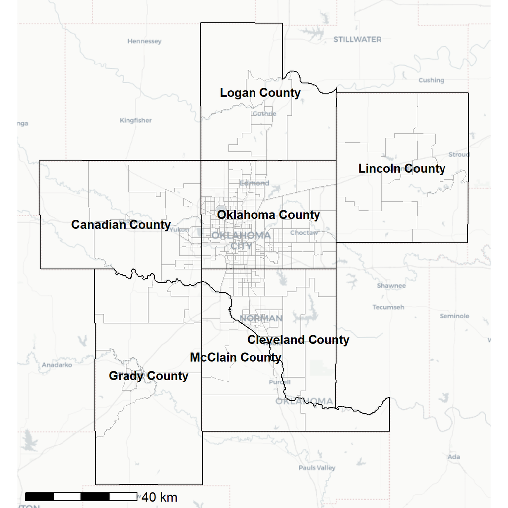

Map showing the counties and census tracts in the Oklahoma City MSA

## Densities

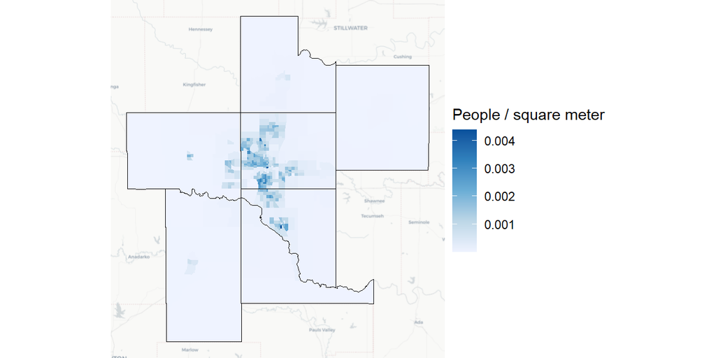

Map showing the population density in the Oklahoma City MSA

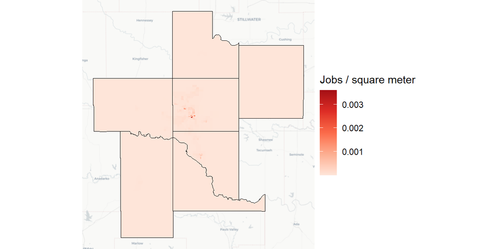

Map showing the employment density in the Oklahoma City MSA

## Employment & Income

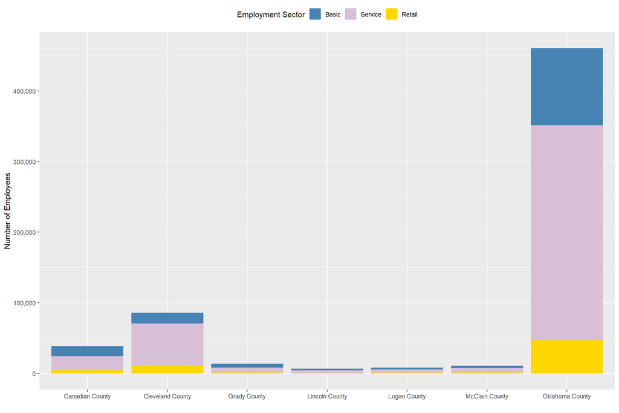

Employment by sector by county

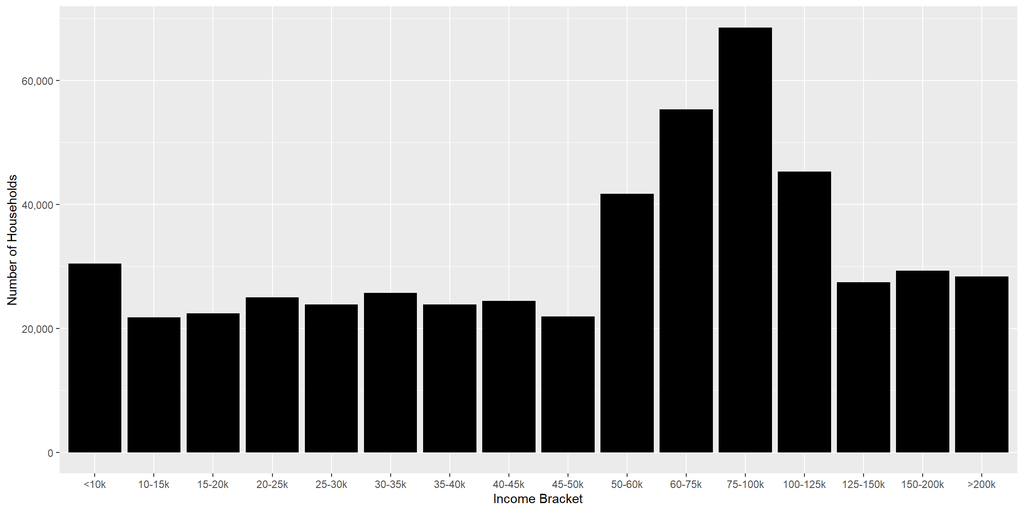

Distribution of households by income bracket

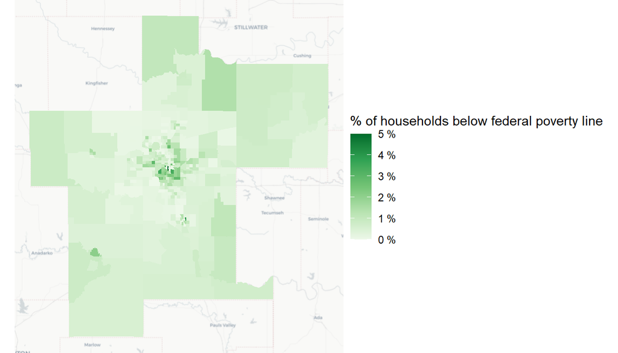

Map showing the spatial distribution of poverty in the Oklahoma City MSA

## Vehicle Ownership

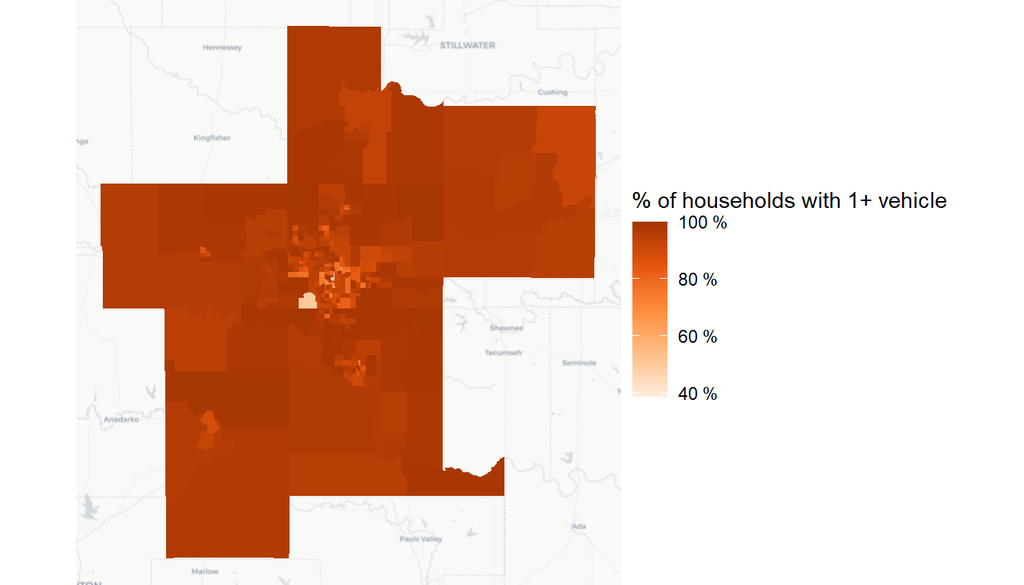

Map showing the spatial distribution of vehicle access in the Oklahoma City MSA

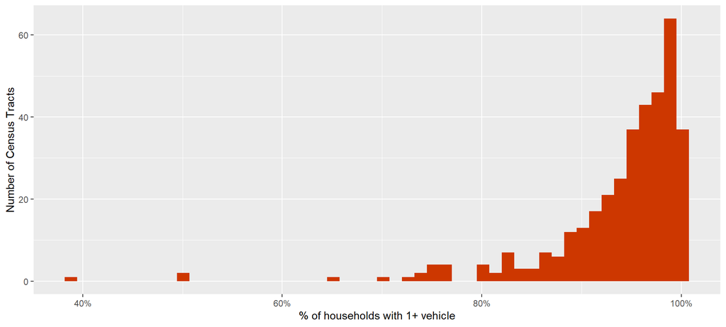

Distribution of cencus tracts by percent of households with access to a vehicle

# Travel Time Matrix: Roads

To create the network in TransCAD, we imported the Open Street Maps layer and selected for primary, secondary, tertiary, and trunk roads. When creating the centroids and centroid connectors, we allowed for the connectors to extend outside of zone boundaries, at up to 30 miles, and up to 10 connectors per centroid. This resulted in a matrix with only a few gaps, which we resolved by turning surrounding roads two-way. (The major roads in the area were separated highways, so we trust that two-way driving is actually feasible in these zones.)

## Isochrones

After generating a complete matrix, we read the travel time matrix and the nodes layer into R. We converted the centroids’ coordinates to a geometry, matched centroid IDs with the appropriate census tracts, and pivoted the travel time matrix so origins and destinations would both be in columns. This allowed us to create an isochrone illustrating the travel time from one zone in the study area to all others.

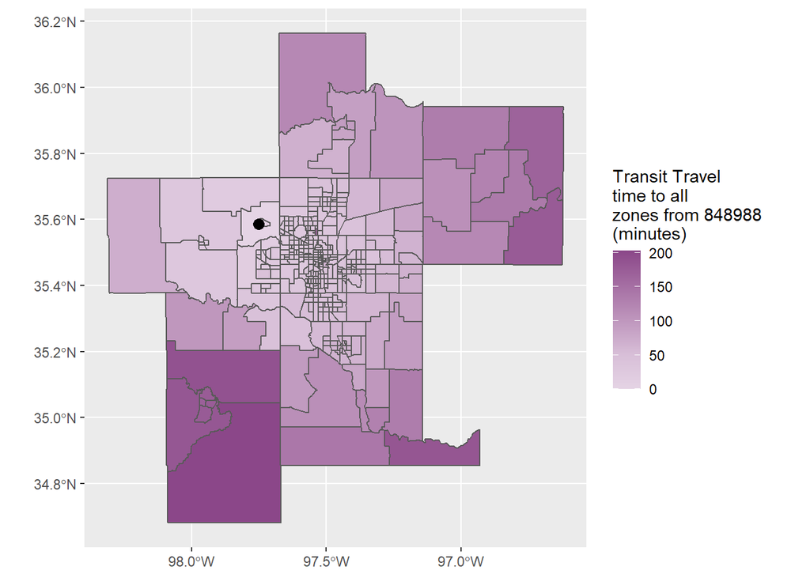

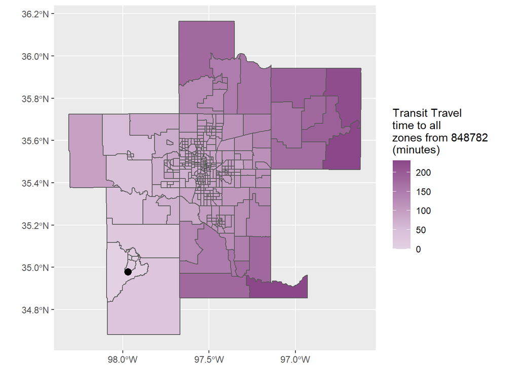

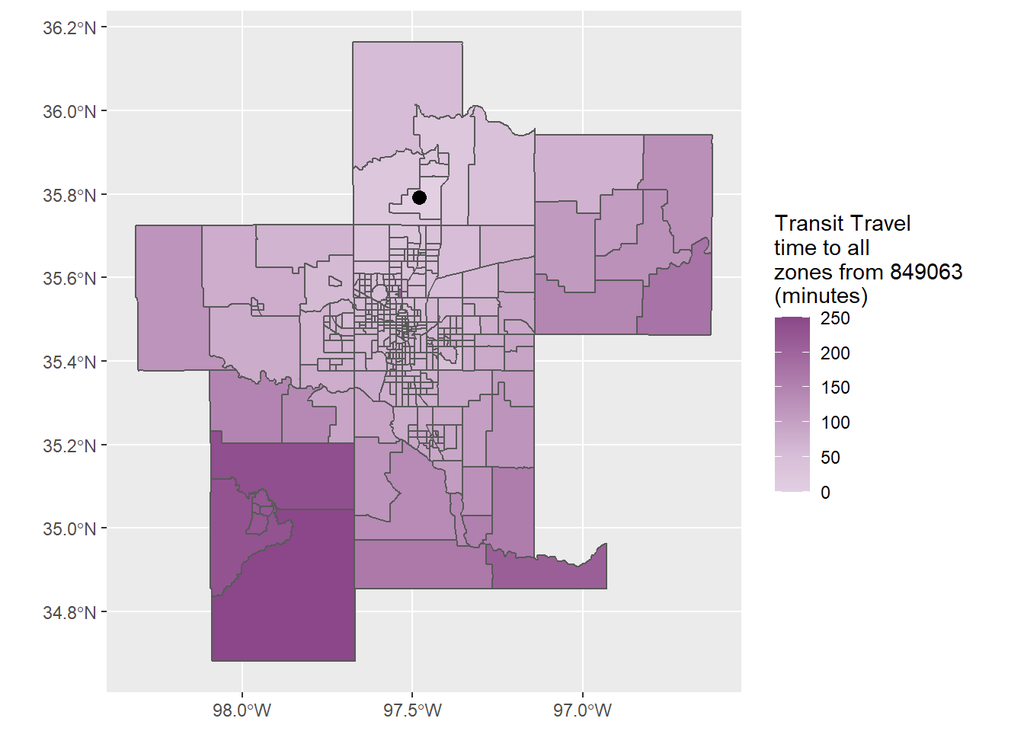

## Accessibility Score

This metric allows us to compare the relative accessibility of tracts more easily. We calculated an “accessibility score” by counting the number of zones each origin could reach within 30 minutes. We note that this score is affected by the lack of residential roads in our network, which would likely provide better accessibility for some of the peripheral zones.

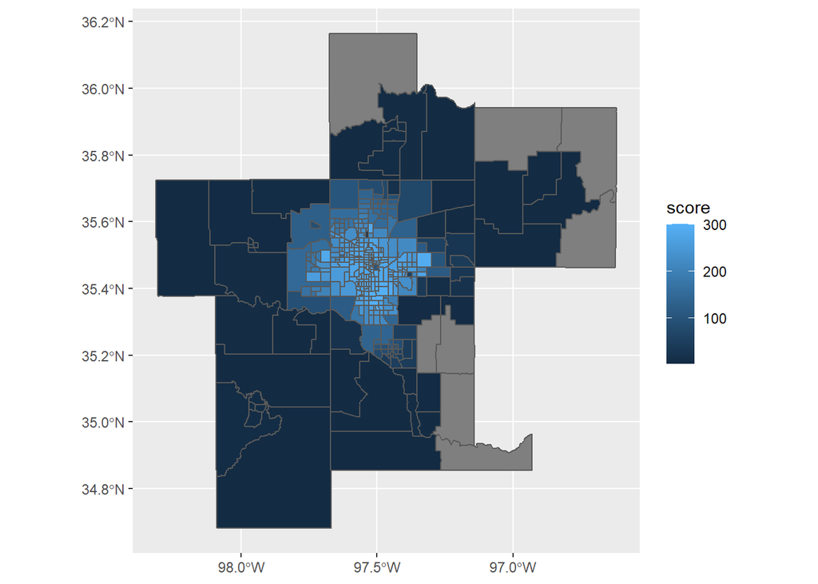